# DataLab Cup 5: You draw I draw

Shan-Hung Wu & DataLab

Fall 2018

## Competition Info

In this competition, you have to output a stroke based on previous sketch generated by you and your opponent. You are provided with [**Quick, Draw! dataset**](https://quickdraw.withgoogle.com/data) as training data and [sketch-rnn](https://github.com/tensorflow/magenta/tree/master/magenta/models/sketch_rnn) as your training model. Your goal is to train a generator that can make the sketch look like class that your model want to draw. In this competiton, we use "**hot air balloon**", "**bulb**", "**ice cream**", "**microphone**" as classes to draw.

### Input format

The input of your model is a sequence of points, and each point is denote by 5 dimension which are ($\Delta x$, $\Delta y$, $p1$, $p2$, $p3$). First 2 $\Delta x,\Delta y$ elements indicate offset distance to previous point. Last 3 elements represents an one-hot vector of pen state, $p1$ indicates that a line will be drawn from current point to next point, $p2$ indicates that a line will not be drawn from current point to next point, $p3$ indicates that the drawing has ended, and subsequent points will not be rendered.

### Output format

A stroke, which is a sequence of points ($\Delta x$, $\Delta y$, $p1$, $p2$, $p3$). The stroke should end with $p2$=1, which indicate the end of this stroke, or $p3$=1, which indeicate the end of sketch.

### Dataset

In the following, we will load some data and demo data format.

```python
# import the required libraries
%matplotlib inline
import matplotlib.pyplot as plt
import numpy as np
np.set_printoptions(precision=8,suppress=True)
import os
os.environ["CUDA_VISIBLE_DEVICES"] = ""

# libraries required for visualisation:
from IPython.display import SVG, display
import svgwrite # conda install -c omnia svgwrite=1.1.6
```

```python
# function used to draw a sketch
def get_bounds(data, factor=10):
  """Return bounds of data."""
  min_x = 0
  max_x = 0
  min_y = 0
  max_y = 0

  abs_x = 0
  abs_y = 0
  for i in range(len(data)):
    x = float(data[i, 0]) / factor
    y = float(data[i, 1]) / factor
    abs_x += x
    abs_y += y
    min_x = min(min_x, abs_x)
    min_y = min(min_y, abs_y)
    max_x = max(max_x, abs_x)
    max_y = max(max_y, abs_y)
  return (min_x, max_x, min_y, max_y)


def draw_strokes(data,
                 svg_filename='/tmp/sketch_rnn/svg/sample.svg',
                 factor=0.2,
                 show_pen_sequence=False,
                 who_draw_the_stroke=None):
  if not os.path.exists(os.path.dirname(svg_filename)):
    os.makedirs(os.path.dirname(svg_filename))
  min_x, max_x, min_y, max_y = get_bounds(data, factor)
  dims = (50 + max_x - min_x, 50 + max_y - min_y)
  dwg = svgwrite.Drawing(svg_filename, size=dims)
  dwg.add(dwg.rect(insert=(0, 0), size=dims, fill='white'))
  lift_pen = 1
  abs_x = 25 - min_x
  abs_y = 25 - min_y
  p = "M%s,%s " % (abs_x, abs_y)
  command = "M"
  xs = []
  ys = []
  for i in range(len(data)):
    if (lift_pen == 1):
      command = "M"
    elif (command != "L"):
      command = "L"
    else:
      command = ""
    x = float(data[i, 0]) / factor
    y = float(data[i, 1]) / factor
    abs_x += x
    abs_y += y
    xs.append(abs_x)
    ys.append(abs_y)
    lift_pen = data[i, 2]
    p += command + str(abs_x) + "," + str(abs_y) + " "
  the_color = "black"
  stroke_width = 1
  dwg.add(dwg.path(p).stroke(the_color, stroke_width).fill("none"))
  color = 'black'
  if show_pen_sequence:
    turn = 0
    for i in range(1, len(xs)):
      dwg.add(
          dwg.text(
              '{}'.format(i),
              insert=(xs[i], ys[i]),
              font_size="10px",
              fill=color))
      if who_draw_the_stroke is not None:
        if data[i, 2] == 1:
          color = 'red' if who_draw_the_stroke[turn] == 1 else 'black'
          turn += 1
  display(SVG(dwg.tostring()))
```

```python
# load data
data = np.load('../dataset/light bulb.full.npz')
train_sketches = data['train']
valid_sketches = data['valid']
test_sketches = data['test']
print('num train: {}'.format(len(train_sketches)))
print('num valid: {}'.format(len(valid_sketches)))
print('num test: {}'.format(len(test_sketches)))
```

```
num train: 104447
num valid: 2500
num test: 2500
```

```python
# see data format and draw it
print(train_sketches[0])
draw_strokes(train_sketches[0], show_pen_sequence=True)
```

```
[[  20   95    0]
 [  10   34    0]
 [  42   -1    0]
 [   4   -1    0]
 [   2   -5    0]
 [ -18  -67    0]
 [  -6  -39    0]
 [  -5  -14    0]
 [   6   -9    0]
 [  15   -7    0]
 [  12  -15    0]
 [   6  -17    0]
 [   0  -22    0]
 [ -11  -26    0]
 [ -19  -14    0]
 [ -16   -6    0]
 [ -32   -7    0]
 [ -46    0    0]
 [ -13    4    0]
 [ -13   11    0]
 [  -9   20    0]
 [   0   26    0]
 [  11   22    0]
 [  28   22    0]
 [  45   21    1]
 [ -11   17    0]
 [  65    2    1]
 [ -58   22    0]
 [  22    7    0]
 [  30    3    1]
 [ -44   16    0]
 [  13    5    0]
 [  19    2    0]
 [  27   -3    1]
 [ -50   27    0]
 [  24    3    0]
 [  18   -3    1]
 [ -74 -122    0]
 [  -5  -35    0]
 [  10   -8    0]
 [  19   -6    0]
 [  13    8    0]
 [   1   14    0]
 [  10   13    0]
 [   7   25    1]]
```

[figure not shown]

As you can see, the raw sketch is stroke-3 format. We will convert it to stroke-5 format and do some preprocessing to make it easier to train.

```python
def preprocess(sketches, limit=1000):
  raw_data = []
  seq_len = []
  count_data = 0

  for i in range(len(sketches)):
    data = sketches[i]
    count_data += 1
    # removes large gaps from the data
    data = np.minimum(data, limit)
    data = np.maximum(data, -limit)
    data = np.array(data, dtype=np.float32)
    raw_data.append(data)
    seq_len.append(len(data))
  seq_len = np.array(seq_len)  # nstrokes for each sketch
  idx = np.argsort(seq_len)
  sketches = []
  for i in range(len(seq_len)):
    sketches.append(raw_data[idx[i]])
  return raw_data


def normalize(sketches):
  """Normalize entire dataset (delta_x, delta_y) to [-1,1]."""
  result = []
  for i in range(len(sketches)):
    tmp = sketches[i]
    sketches[i][:, :2] /= np.max(np.abs(sketches[i][:, :2]))
    result.append(tmp)
  return result


def to_big_strokes(strokes):
  """Converts from stroke-3 to stroke-5 format and pads to given length, but does not insert special start token)."""

  result = np.zeros((len(strokes), 5), dtype=float)
  l = len(strokes)
  result[0:l, 0:2] = strokes[:, 0:2]
  result[0:l, 3] = strokes[:, 2]
  result[0:l, 2] = 1 - result[0:l, 3]
  result[l:, 4] = 1
  return result


def to_big_sketches(sketches):
  result = []
  for i in range(len(sketches)):
    sketch = to_big_strokes(sketches[i])
    result.append(sketch)
  return result


def to_normal_strokes(big_strokes):
  """Convert from stroke-5 format (from sketch-rnn paper) back to stroke-3."""
  l = 0
  for i in range(len(big_strokes)):
    if big_strokes[i, 4] > 0:
      l = i
      break
  if l == 0:
    l = len(big_strokes)
  result = np.zeros((l, 3))
  result[:, 0:2] = big_strokes[0:l, 0:2]
  result[:, 2] = big_strokes[0:l, 3]
  return result
```

```python
# preprocess sketches
train_sketches = preprocess(train_sketches)
valid_sketches = preprocess(valid_sketches)
test_sketches = preprocess(test_sketches)

train_sketches = normalize(train_sketches)
valid_sketches = normalize(valid_sketches)
test_sketches = normalize(test_sketches)

# convert to stroke-5 format
train_sketches = to_big_sketches(train_sketches)
valid_sketches = to_big_sketches(valid_sketches)
test_sketches = to_big_sketches(test_sketches)
```

in the following, we demo normalized data.

```python
print(to_normal_strokes(train_sketches[0]))
draw_strokes(to_normal_strokes(train_sketches[0]))
```

```
[[ 0.16393442  0.77868855  0.        ]
 [ 0.08196721  0.27868852  0.        ]
 [ 0.3442623  -0.00819672  0.        ]
 [ 0.03278688 -0.00819672  0.        ]
 [ 0.01639344 -0.04098361  0.        ]
 [-0.14754099 -0.54918033  0.        ]
 [-0.04918033 -0.31967214  0.        ]
 [-0.04098361 -0.1147541   0.        ]
 [ 0.04918033 -0.07377049  0.        ]
 [ 0.12295082 -0.05737705  0.        ]
 [ 0.09836066 -0.12295082  0.        ]
 [ 0.04918033 -0.13934426  0.        ]
 [ 0.         -0.18032786  0.        ]
 [-0.09016393 -0.21311475  0.        ]
 [-0.1557377  -0.1147541   0.        ]
 [-0.13114753 -0.04918033  0.        ]
 [-0.26229507 -0.05737705  0.        ]
 [-0.37704918  0.          0.        ]
 [-0.10655738  0.03278688  0.        ]
 [-0.10655738  0.09016393  0.        ]
 [-0.07377049  0.16393442  0.        ]
 [ 0.          0.21311475  0.        ]
 [ 0.09016393  0.18032786  0.        ]
 [ 0.22950819  0.18032786  0.        ]
 [ 0.36885247  0.17213115  1.        ]
 [-0.09016393  0.13934426  0.        ]
 [ 0.53278691  0.01639344  1.        ]
 [-0.47540984  0.18032786  0.        ]
 [ 0.18032786  0.05737705  0.        ]
 [ 0.24590164  0.02459016  1.        ]
 [-0.36065573  0.13114753  0.        ]
 [ 0.10655738  0.04098361  0.        ]
 [ 0.1557377   0.01639344  0.        ]
 [ 0.22131148 -0.02459016  1.        ]
 [-0.40983605  0.22131148  0.        ]
 [ 0.19672132  0.02459016  0.        ]
 [ 0.14754099 -0.02459016  1.        ]
 [-0.60655737 -1.          0.        ]
 [-0.04098361 -0.28688523  0.        ]
 [ 0.08196721 -0.06557377  0.        ]
 [ 0.1557377  -0.04918033  0.        ]
 [ 0.10655738  0.06557377  0.        ]
 [ 0.00819672  0.1147541   0.        ]
 [ 0.08196721  0.10655738  0.        ]
 [ 0.05737705  0.20491803  1.        ]]
```

In the following, we draw first 100 sketches to see how it look like.

```python
# generate a 2D grid of many vector drawings
def make_grid_svg(s_list, grid_space=10.0, grid_space_x=16.0):

  def get_start_and_end(x):
    x = np.array(x)
    x = x[:, 0:2]
    x_start = x[0]
    x_end = x.sum(axis=0)
    x = x.cumsum(axis=0)
    x_max = x.max(axis=0)
    x_min = x.min(axis=0)
    center_loc = (x_max + x_min) * 0.5
    return x_start - center_loc, x_end

  x_pos = 0.0
  y_pos = 0.0
  result = [[x_pos, y_pos, 1]]
  for sample in s_list:
    s = sample[0]
    grid_loc = sample[1]
    grid_y = grid_loc[0] * grid_space + grid_space * 0.5
    grid_x = grid_loc[1] * grid_space_x + grid_space_x * 0.5
    start_loc, delta_pos = get_start_and_end(s)

    loc_x = start_loc[0]
    loc_y = start_loc[1]
    new_x_pos = grid_x + loc_x
    new_y_pos = grid_y + loc_y
    result.append([new_x_pos - x_pos, new_y_pos - y_pos, 0])

    result += s.tolist()
    result[-1][2] = 1
    x_pos = new_x_pos + delta_pos[0]
    y_pos = new_y_pos + delta_pos[1]
  return np.array(result)
```

```python
sketches_grid = []
for i in range(10):
  for j in range(10):
    sketches_grid.append(
        [to_normal_strokes(train_sketches[i * 10 + j]), [i, j]])
sketches_grid = make_grid_svg(sketches_grid)
draw_strokes(sketches_grid)
```

[output not shown]

## Stroke length histogram

We have calculated the histogram stroke length of 4 classess. We select 10 as max stroke length of model's output.

[figure not shown]

## Model: Sketch-RNN

[figure not shown]

We can use deocder-only sketch-rnn to learn the task, Which we don't feed the noise and prior input sketch.

[figure not shown]

Above graph detail what GMM softmax sample is doing, the model first output (num_mixture*6 + 3) dimension hidden vector, and then

1. extract (num_mixture*5) dimension as parameters of (num_mixture) bivaraiate Gaussian, and sample ($\Delta x, \Delta y$) from them.
2. extract (num_mixture) dimension as weight of each bivariate Gaussian.
3. extract 3 dimension as probabilty of pen state.
4. concatenate ($\Delta x, \Delta y$) and pen state to get next point.

The folloing model is modified from [sketch-rnn](https://github.com/tensorflow/magenta/tree/master/magenta/models/sketch_rnn)

```python
# import the required libraries
import time
import random
import json
import tensorflow as tf
```

```python
# function used to generate next point
def adjust_temp(pi_pdf, temp):
  pi_pdf = np.log(pi_pdf) / temp
  pi_pdf -= pi_pdf.max()
  pi_pdf = np.exp(pi_pdf)
  pi_pdf /= pi_pdf.sum()
  return pi_pdf


def get_pi_idx(x, pdf, temp=1.0, greedy=False):
  """Samples from a pdf, optionally greedily."""
  if greedy:
    return np.argmax(pdf)
  pdf = adjust_temp(np.copy(pdf), temp)
  accumulate = 0
  for i in range(0, pdf.size):
    accumulate += pdf[i]
    if accumulate >= x:
      return i
  tf.logging.info('Error with sampling ensemble.')
  return -1


def sample_gaussian_2d(mu1, mu2, s1, s2, rho, temp=1.0, greedy=False):
  if greedy:
    return mu1, mu2
  mean = [mu1, mu2]
  s1 *= temp * temp
  s2 *= temp * temp
  cov = [[s1 * s1, rho * s1 * s2], [rho * s1 * s2, s2 * s2]]
  x = np.random.multivariate_normal(mean, cov, 1)
  return x[0][0], x[0][1]
```

```python
class SRNN_Model():

  def __init__(self, hps, model_name='sketch_rnn'):
    self.hps = hps
    self.model_name = model_name
    with tf.variable_scope(model_name, reuse=tf.AUTO_REUSE):
      self.build_model(hps)

  def build_model(self, hps):

    # input and output
    self.batch_size = tf.placeholder(
        dtype=tf.int32, shape=[], name='batch_size')
    self.input_sequence = tf.placeholder(
        dtype=tf.float32,
        shape=[None, hps.max_seq_len + 1, 5],
        name='input_sequence')
    input_sequence = self.input_sequence[:, :-1]
    output_sequence = self.input_sequence[:, 1:, :]
    self.lstm_cell = tf.nn.rnn_cell.LSTMCell(hps.dec_rnn_size)
    self.zero_state = self.lstm_cell.zero_state(self.batch_size, tf.float32)
    output, _ = tf.nn.dynamic_rnn(
        self.lstm_cell, input_sequence, initial_state=self.zero_state)
    output = tf.reshape(output, [-1, hps.dec_rnn_size])

    # for each input timestamp, output parameters for mixture of gaussian
    num_hidden = hps.num_mixture * 6 + 3

    def feed_forward(output):
      with tf.variable_scope('feed_forward', reuse=tf.AUTO_REUSE):
        return tf.layers.dense(output, num_hidden)

    output = feed_forward(output)
    ##############################################################################
    """
        Loss for mixture of multivariate gaussian. Given (prev_delta_x, prev_delta_y, prev_p1, prev_p2, prev_p3),
        we want the mixture to output high probility P(delta_x, delta_y|prev_delta_x, prev_delta_y, prev_p1, prev_p2, prev_p3),
        see equation (9) at https://arxiv.org/pdf/1704.03477.pdf

        parameters:
            pi: weight of each mixture, shape (batch_size*max_seq_len, num_mixture)
            mu1, mu2: mu of (delta_x, delta_y), shape (batch_size*max_seq_len, num_mixture)
            sigma1, sigma2: sigma of (delta_x, delta_y), shape (batch_size*max_seq_len, num_mixture)
            corr: correction of (delta_x, delta_y), shape (batch_size*max_seq_len, num_mixture)
        """
    output_params = tf.split(
        output, num_or_size_splits=[3] + [hps.num_mixture] * 6, axis=1)
    output_pen_logits, output_mixture_pi, output_mu1, output_mu2, output_sigma1, output_sigma2, output_corr = output_params

    # softmax all the pi's and pen states:
    output_mixture_pi = tf.nn.softmax(output_mixture_pi)
    output_pen_pi = tf.nn.softmax(output_pen_logits)

    # exponentiate the sigmas and also make corr between -1 and 1.
    output_sigma1 = tf.exp(output_sigma1)
    output_sigma2 = tf.exp(output_sigma2)
    output_corr = tf.tanh(output_corr)

    x1 = tf.reshape(output_sequence[:, :, 0], [-1, 1])
    x2 = tf.reshape(output_sequence[:, :, 1], [-1, 1])

    def tf_2d_normal(x1, x2, mu1, mu2, s1, s2, rho):
      """
            Returns P(delta_x, delta_y|prev_delta_x, prev_delta_y, prev_p1, prev_p2, prev_p3),
            see equation (24) of http://arxiv.org/abs/1308.0850 or
            https://en.wikipedia.org/wiki/Multivariate_normal_distribution#Bivariate_case
            """
      norm1 = tf.subtract(x1, mu1)
      norm2 = tf.subtract(x2, mu2)
      s1s2 = tf.multiply(s1, s2)
      # eq 25
      z = (tf.square(tf.div(norm1, s1)) + tf.square(tf.div(norm2, s2)) -
           2 * tf.div(tf.multiply(rho, tf.multiply(norm1, norm2)), s1s2))
      neg_rho = 1 - tf.square(rho) + 1e-6  # avoid divide by zero
      result = tf.exp(tf.div(-z, 2 * neg_rho))
      denom = 2 * np.pi * tf.multiply(s1s2, tf.sqrt(neg_rho))
      result = tf.div(result, denom)
      self.denom = denom
      self.neg_rho = neg_rho
      self.s1s2 = s1s2
      self.s1 = s1
      self.s2 = s2
      return result

    point_prob = tf_2d_normal(x1, x2, output_mu1, output_mu2, output_sigma1,
                              output_sigma2, output_corr)
    point_prob = tf.multiply(
        point_prob, output_mixture_pi)  # multiply weight of each mixture
    point_prob = tf.reduce_sum(point_prob, axis=1)

    # loss for indicating if pen should stop
    pen_labels = tf.reshape(output_sequence[:, :, 2:],
                            [-1, 3])  # (batch_size*max_seq_len ,3)
    pen_loss = tf.nn.softmax_cross_entropy_with_logits_v2(
        labels=pen_labels, logits=output_pen_logits)
    self.pen_loss = tf.reduce_mean(pen_loss)

    # loss for delta x,y
    delta_xy_loss = -tf.log(point_prob + 1e-6)  # avoid log(0)
    mask = 1.0 - pen_labels[:, 2]
    mask = tf.reshape(mask, [-1, 1])
    delta_xy_loss = delta_xy_loss * mask
    self.delta_xy_loss = tf.reduce_mean(delta_xy_loss)

    self.loss = self.pen_loss + self.delta_xy_loss

    # optimize rnn
    self.global_step = tf.get_variable(
        name='global_step', initializer=tf.constant(0.), trainable=False)
    self.learning_rate = tf.get_variable(
        name='learning_rate',
        initializer=tf.constant(hps.learning_rate),
        trainable=False)
    optimizer = tf.train.AdamOptimizer(self.learning_rate)
    var_list = tf.get_collection(tf.GraphKeys.TRAINABLE_VARIABLES,
                                 self.model_name + '/')
    grad_vars = optimizer.compute_gradients(self.loss, var_list=var_list)
    grad_vars = [(tf.clip_by_value(grad, -hps.grad_clip, hps.grad_clip), var)
                 for grad, var in grad_vars]
    self.train_op = optimizer.apply_gradients(
        grad_vars, global_step=self.global_step, name='train_step')

    #################### tensor for generating a point ############################
    self.prev_state = self.lstm_cell.zero_state(1, dtype=tf.float32)
    self.prev_point = tf.placeholder(
        tf.float32, shape=[1, 5], name='prev_point')
    output, self.next_state = self.lstm_cell(self.prev_point, self.prev_state)
    output = tf.reshape(output, [-1, hps.dec_rnn_size])
    output = feed_forward(output)
    self.output_pi, self.output_mu1, self.output_mu2, self.output_sigma1, self.output_sigma2, self.output_corr = \
                                                          tf.split(output[:,3:], num_or_size_splits=6, axis=1)
    pen_logits = output[:, :3]
    self.output_pi = tf.nn.softmax(self.output_pi)
    self.pen_pi = tf.nn.softmax(pen_logits)
    self.output_sigma1 = tf.exp(self.output_sigma1)
    self.output_sigma2 = tf.exp(self.output_sigma2)
    self.output_corr = tf.tanh(self.output_corr)
```

```python
  def generate_stroke(self, sess, prev_sketch, temperature=0.1, greedy=False):
    """
        *****************************IMPORTANT*****************************
        1. your model must have this function, or error happen when evaluation.
        2. the length of stroke must less than 10, which means you can at most generate 10 points.
        *******************************************************************
        this function return a stroke given previous generated sketch
        """
    # feed previous sketch to get hidden state
    prev_state = sess.run(self.zero_state, feed_dict={self.batch_size: 1})
    for i in range(len(prev_sketch) - 1):
      feed_dict = {
          self.prev_state: prev_state,
          self.prev_point: [prev_sketch[i]],
      }
      prev_state = sess.run(self.next_state, feed_dict)

    # start to generate next stroke
    prev_point = [prev_sketch[-1]]
    generated_stroke = []
    while len(generated_stroke) < 10:
      feed_dict = {
          self.prev_state: prev_state,
          self.prev_point: prev_point,
      }
      params = sess.run([
          self.output_pi, self.output_mu1, self.output_mu2, self.output_sigma1,
          self.output_sigma2, self.output_corr, self.pen_pi, self.next_state
      ], feed_dict)

      [o_pi, o_mu1, o_mu2, o_sigma1, o_sigma2, o_corr, o_pen,
       next_state] = params

      # sample index of bivarite normal in mixture to use
      idx = get_pi_idx(np.random.random(), o_pi[0], temperature, greedy)

      # sample index of pen state
      idx_eos = get_pi_idx(np.random.random(), o_pen[0], temperature, greedy)
      eos = [0, 0, 0]
      eos[idx_eos] = 1

      # use one bivarite normal to generate next (delta_x, delta_y)
      next_x1, next_x2 = sample_gaussian_2d(o_mu1[0][idx], o_mu2[0][idx],
                                            o_sigma1[0][idx], o_sigma2[0][idx],
                                            o_corr[0][idx],
                                            np.sqrt(temperature), greedy)

      prev_point = np.zeros([1, 5])
      prev_point[0, :] = [next_x1, next_x2, eos[0], eos[1], eos[2]]
      prev_state = next_state
      generated_stroke.append(prev_point)

      # if this stroke stop
      if prev_point[0][4] == 1:
        generated_stroke[-1][0][:2] = 0
      if prev_point[0][4] == 1 or prev_point[0][3] == 1:
        break
    # pen state should end with p2=1 or p3=1
    if generated_stroke[-1][0][2] == 1:
      generated_stroke[-1][0][2:] = [0., 1., 0.]
    return np.concatenate(generated_stroke, axis=0)

  def generate_sketches(self, sess, num_generate, temperature, greedy=False):
    initial_point = np.array([[0., 0., 1., 0., 0.]])
    initial_state = sess.run(self.zero_state, feed_dict={self.batch_size: 1})
    return_sketches = []
    for i in range(num_generate):
      sketch = [initial_point]
      prev_point = initial_point
      prev_state = initial_state
      for j in range(self.hps.max_seq_len):
        feed_dict = {
            self.prev_state: prev_state,
            self.prev_point: prev_point,
        }
        params = sess.run([
            self.output_pi, self.output_mu1, self.output_mu2,
            self.output_sigma1, self.output_sigma2, self.output_corr,
            self.pen_pi, self.next_state
        ], feed_dict)

        [o_pi, o_mu1, o_mu2, o_sigma1, o_sigma2, o_corr, o_pen,
         next_state] = params
        idx = get_pi_idx(random.random(), o_pi[0], temperature, greedy)

        idx_eos = get_pi_idx(random.random(), o_pen[0], temperature, greedy)
        eos = [0, 0, 0]
        eos[idx_eos] = 1

        next_x1, next_x2 = sample_gaussian_2d(o_mu1[0][idx], o_mu2[0][idx],
                                              o_sigma1[0][idx],
                                              o_sigma2[0][idx], o_corr[0][idx],
                                              np.sqrt(temperature), greedy)

        prev_point = np.zeros([1, 5])
        prev_point[0, :] = [next_x1, next_x2, eos[0], eos[1], eos[2]]
        prev_state = next_state

        # select a multivariate normal in mixture to draw next point
        sketch.append(prev_point)
        if prev_point[0][4] == 1:
          sketch[-1][0][:2] = 0
          break
      return_sketches.append(np.concatenate(sketch, axis=0))
    return return_sketches

  def train(self,
            sess,
            x_train,
            x_valid,
            x_test,
            num_epoch=20,
            batch_size=100,
            patience=20):
    start = time.time()
    best_valid_cost = np.inf
    counter = 0
    for epoch in range(num_epoch):

      def gen_batch(x):
        shuffle_idx = np.random.permutation(len(x))
        x = x[shuffle_idx]
        num_batch = len(x) // batch_size
        for i in range(num_batch):
          yield x[i * batch_size:(i + 1) * batch_size]

      losses = []
      delta_xy_losses = []
      pen_losses = []
      for x_batch in gen_batch(x_train):
        step = sess.run(self.global_step)
        curr_learning_rate = ((hps.learning_rate - hps.min_learning_rate) *
                              (hps.decay_rate)**step + hps.min_learning_rate)
        feed_dict = {
            self.input_sequence: x_batch,
            self.learning_rate: curr_learning_rate,
            self.batch_size: len(x_batch)
        }
        (loss, delta_xy_loss, pen_loss, _) = sess.run(
            [self.loss, self.delta_xy_loss, self.pen_loss,
             self.train_op], feed_dict)
        losses.append(loss)
        delta_xy_losses.append(delta_xy_loss)
        pen_losses.append(pen_loss)
        if step % 20 == 0 and step > 0:
          end = time.time()
          time_taken = end - start
          tf.logging.info((
              'step: {}, learning_rate: {:.4f}, loss: {:.4f}, xy_loss: {:.4f}, '
              + 'pen_loss: {:.4f}, time_taken: {:.2f}').format(
                  step, curr_learning_rate,
                  np.mean(losses),
                  np.mean(delta_xy_losses), np.mean(pen_losses), time_taken))
          losses = []
          delta_xy_losses = []
          pen_losses = []
          start = time.time()
        if step % 1000 == 0 and step > 0:
          N = 10
          sketches = self.generate_sketches(
              sess, num_generate=N, temperature=0.5)
          reconstructions = []
          for i in range(N):
            reconstructions.append([to_normal_strokes(sketches[i]), [0, i]])
          stroke_grid = make_grid_svg(reconstructions)
          draw_strokes(stroke_grid)
```

```python
        if step % self.hps.save_every == 0 and step > 0:
          start = time.time()
          test_losses = []
          test_delta_xy_losses = []
          test_pen_losses = []
          for x_batch in gen_batch(x_valid):
            feed_dict = {
                self.input_sequence: x_batch,
                self.batch_size: len(x_batch)
            }

            (loss, delta_xy_loss, pen_loss) = sess.run(
                [self.loss, self.delta_xy_loss, self.pen_loss], feed_dict)
            test_losses.append(loss)
            test_delta_xy_losses.append(delta_xy_loss)
            test_pen_losses.append(pen_loss)

          end = time.time()
          time_taken = end - start
          tf.logging.info(
              ('validation, step: {}, loss: {:.4f}, xy_loss: {:.4f}, ' +
               'pen_loss: {:.4f}, time_taken: {:.2f}').format(
                   step,
                   np.mean(test_losses),
                   np.mean(test_delta_xy_losses),
                   np.mean(test_pen_losses), time_taken))
          start = time.time()

          if np.mean(test_losses) < best_valid_cost:
            best_valid_cost = np.mean(test_losses)
            self.save_model(sess, step=step)
            test_losses = []
            test_delta_xy_losses = []
            test_pen_losses = []
            for x_batch in gen_batch(x_test):
              feed_dict = {
                  self.input_sequence: x_batch,
                  self.batch_size: len(x_batch)
              }

              (loss, delta_xy_loss, pen_loss) = sess.run(
                  [self.loss, self.delta_xy_loss, self.pen_loss], feed_dict)
              test_losses.append(loss)
              test_delta_xy_losses.append(delta_xy_loss)
              test_pen_losses.append(pen_loss)

            end = time.time()
            time_taken = end - start
            tf.logging.info(
                ('testing, step: {}, loss: {:.4f}, xy_loss: {:.4f}, ' +
                 'pen_loss: {:.4f}, time_taken: {:.2f}').format(
                     step,
                     np.mean(test_losses),
                     np.mean(test_delta_xy_losses),
                     np.mean(test_pen_losses), time_taken))
            counter = 0
          else:
            counter += 1
            if counter > patience:
              tf.logging.info('early stop!!')
              return

  def save_model(self, sess, checkpoint_dir='./checkpoints', step=None):
    if not os.path.exists(checkpoint_dir):
      os.makedirs(checkpoint_dir)
    saver = tf.train.Saver(
        tf.get_collection(tf.GraphKeys.TRAINABLE_VARIABLES, self.model_name +
                          '/'))
    if step is not None:
      saver.save(
          sess, os.path.join(checkpoint_dir, self.model_name), global_step=step)
      tf.logging.info('model save to {}-{}'.format(
          os.path.join(checkpoint_dir, self.model_name), step))
    else:
      saver.save(sess, os.path.join(checkpoint_dir, self.model_name))
      tf.logging.info('model save to {}'.format(
          os.path.join(checkpoint_dir, self.model_name)))

  def load_model(self, sess, checkpoint_dir='./checkpoints', step=None):
    """
        *****************************IMPORTANT*****************************
        1. your model must have this function, or error happen when evaluation.
        *******************************************************************
        this function load weight to sess
        """
    saver = tf.train.Saver(
        tf.get_collection(tf.GraphKeys.TRAINABLE_VARIABLES, self.model_name +
                          '/'))
    if step is not None:
      saver.restore(sess,
                    os.path.join(checkpoint_dir,
                                 self.model_name + '-{}'.format(step)))
    else:
      saver.restore(sess, os.path.join(checkpoint_dir, self.model_name))
```

In the following, we insert start token and pad each sketch to make them have same length.

```python
def pad_data(sketches, max_seq_len):
  """Pad the batch to be stroke-5 bigger format as described in paper."""
  result = np.zeros((len(sketches), max_seq_len + 1, 5), dtype=float)
  for i in range(len(sketches)):
    l = len(sketches[i])
    result[i, 0:l, :] = sketches[i][:, :]
    result[i, l:, 4] = 1

    # put in the first token, as described in sketch-rnn methodology
    result[i, 1:, :] = result[i, :-1, :]
    result[i, 0, :] = 0
    result[i, 0, 2] = 1  # setting S_0 from paper.
  return result


def get_max_len(sketches):
  """Return the maximum length of an array of strokes."""
  max_len = 0
  for sketch in sketches:
    ml = len(sketch)
    if ml > max_len:
      max_len = ml
  return max_len
```

```python
# get max sequence length and pad data
max_seq_len = get_max_len(train_sketches)
x_train = pad_data(train_sketches, max_seq_len)
x_valid = pad_data(valid_sketches, max_seq_len)
x_test = pad_data(test_sketches, max_seq_len)
```

```python
def copy_hparams(hparams):
  """Return a copy of an HParams instance."""
  return tf.contrib.training.HParams(**hparams.values())


def get_default_hparams():
  """Return default HParams for sketch-rnn."""
  hparams = tf.contrib.training.HParams(
      data_set=['aaron_sheep.npz'],  # Our dataset.
      save_every=2000,  # Number of batches per checkpoint creation.
      max_seq_len=250,  # Not used. Will be changed by model. [Eliminate?]
      dec_rnn_size=1024,  # Size of decoder.
      batch_size=100,  # Minibatch size. Recommend leaving at 100.
      grad_clip=1.0,  # Gradient clipping. Recommend leaving at 1.0.
      num_mixture=20,  # Number of mixtures in Gaussian mixture model.
      learning_rate=0.001,  # Learning rate.
      decay_rate=0.9999,  # Learning rate decay per minibatch.
      kl_decay_rate=0.99995,  # KL annealing decay rate per minibatch.
      min_learning_rate=0.00001,  # Minimum learning rate.
      use_recurrent_dropout=True,  # Dropout with memory loss. Recomended
      recurrent_dropout_prob=0.90,  # Probability of recurrent dropout keep.
      use_input_dropout=False,  # Input dropout. Recommend leaving False.
      input_dropout_prob=0.90,  # Probability of input dropout keep.
      use_output_dropout=False,  # Output droput. Recommend leaving False.
      output_dropout_prob=0.90,  # Probability of output dropout keep.
      random_scale_factor=0.15,  # Random scaling data augmention proportion.
      augment_stroke_prob=0.10,  # Point dropping augmentation proportion.
      conditional=True,  # When False, use unconditional decoder-only model.
      is_training=True  # Is model training? Recommend keeping true.
  )
  return hparams
```

```python
hps = get_default_hparams()
hps.max_seq_len = max_seq_len
```

```python
tf.reset_default_graph()
tf.set_random_seed(123)
np.random.seed(123)
random.seed(123)
model = SRNN_Model(hps, model_name='bulb-balloon-60')

config = tf.ConfigProto()
config.gpu_options.allow_growth = True
sess = tf.Session(config=config)
sess.run(tf.global_variables_initializer())
```

In the following, we load pre-trained model to draw sketch.

```python
# model.train(sess, x_train, x_valid, x_test, num_epoch=20, batch_size=100)
model.load_model(sess)
```

```
INFO:tensorflow:Restoring parameters from ./checkpoints/bulb-balloon-60
```

```python
sketches_grid = []
sketches = model.generate_sketches(sess, num_generate=100, temperature=0.5)
for i in range(10):
  for j in range(10):
    sketch = to_normal_strokes(sketches[i * 10 + j])
    sketch[:, :2] *= 2
    sketches_grid.append([sketch, [i, j]])
sketches_grid = make_grid_svg(sketches_grid)
draw_strokes(sketches_grid)
```

[output not shown]

## The Game

The game will start by feeding a starting point to your model or your opponent's model. You and your opponent will alternately output a stroke to make sketch longer and longer. There are some rules in games:

1. Only after turn 4, sketch is evaluated.
2. After a sketch is evaluated, if its predicted probability higher than a threshold, the games ends, otherwise game continues.
3. if player output a stroke indicating end of sketch, the player can't output stroke anymore. The other player has chance to continually generate strokes.
4. The game continues until the sequence is longer than a threshold or both players output a stroke indicating end of sketch. If no class has probability higher than threshold, the game is draw.
5. To prevent a player trying to destroy sketch to make it draw, our classifier have 5th class "other classes". If the stroke you drew make the sketch drop in this class, you will be punished.

## Evaluation

We first play games, at evalation time, we will convert sketches generated in games to images and use a pretrained classifier to predict probability of classes and used it as score. The higher score wins the game. please see codes below.

The following code define how we convert sketch to images and the classifier we use to predict class. We won't give you the weight of classifier. You need to train your own one to evaluate how good your sketch-model is.

```python
def render_imgs(strokes, img_size, max_seq_len):
  """
    convert 5-strokes format to image
        args:
            sketches: shape(data_size, max_seq_len, 5)
    """

  xy = np.cumsum(strokes[:, :, 0:2], axis=1)  # (data_size, max_seq, 2)
  min_xy = np.min(xy, axis=(1), keepdims=True)  # (data_size, 1, 2)
  xy = xy - min_xy  # (data_size, max_seq, 2)
  max_xy = np.max(xy, axis=(1), keepdims=True)  # (data_size, 1, 2)
  max_xy = np.where(max_xy == 0, np.ones([len(strokes), 1, 2]),
                    max_xy)  # avoid divide by 0
  xy = xy / max_xy  # (data_size, max_seq, 2)
  xy = xy * (img_size - 1)  # (data_size, max_seq, 2)

  strokes_idx = np.tile(np.arange(len(strokes))[:, None],
                        [1, img_size])  # (data_size, img_size)
  interpolate_line = np.tile(
      np.reshape(
          np.arange(img_size).astype(np.float32) / (img_size - 1),
          [1, img_size, 1]), [len(strokes), 1, 2])

  def interpolate(p1, p2):
    p1 = np.reshape(p1, [-1, 1, 2])
    p2 = np.reshape(p2, [-1, 1, 2])
    return (1 - interpolate_line
           ) * p1 + interpolate_line * p2  # (data_size, img_size, 2)

  images = np.zeros([len(strokes), img_size, img_size])
  render_next = np.ones(len(images), dtype=np.bool)
  for idx in range(max_seq_len - 1):
    p1 = xy[:, idx]
    p2 = xy[:, idx + 1]
    # if p1 is connect to p2, draw a line between them
    connect = np.where(
        np.logical_and(strokes[:, idx, 3] > strokes[:, idx, 2],
                       strokes[:, idx, 3] > strokes[:, idx, 4]),
        np.zeros(len(images), dtype=np.bool),
        np.ones(len(images), dtype=np.bool))

    p_interpolate_line = interpolate(p1, p2).astype(
        np.int32)  # (data_size, img_size, 2)
    x_idx = np.where(connect[:, None], p_interpolate_line[:, :, 0],
                     np.tile(xy[:, idx, None, 0], [1,
                                                   img_size]).astype(np.int32))
    y_idx = np.where(connect[:, None], p_interpolate_line[:, :, 1],
                     np.tile(xy[:, idx, None, 1], [1,
                                                   img_size]).astype(np.int32))
    images[strokes_idx, x_idx, y_idx] = 1
  images = np.rot90(images, -1, axes=(1, 2))
  return images


class Evaluate_model:

  def __init__(self, image_size, model_name='evaluate_model'):
    with tf.variable_scope(model_name, reuse=tf.AUTO_REUSE):
      self.input_x = tf.placeholder(
          tf.float32, [None, image_size, image_size], name="input_x")
      self.labels = tf.placeholder(tf.int32, [None], name="input_y")
      self.keep_rate = tf.placeholder(tf.float32, [], name="keep_rate")

      hidden = tf.reshape(self.input_x, [-1, image_size, image_size, 1])
      hidden = tf.layers.conv2d(
          hidden,
          filters=64,
          kernel_size=5,
          activation=tf.nn.relu,
          padding='same')
      hidden = tf.nn.lrn(
          hidden, 4, bias=1.0, alpha=0.001 / 9.0, beta=0.75, name='norm1')
      hidden = tf.layers.conv2d(
          hidden,
          filters=64,
          kernel_size=5,
          activation=tf.nn.relu,
          padding='same')
      hidden = tf.nn.lrn(
          hidden, 4, bias=1.0, alpha=0.001 / 9.0, beta=0.75, name='norm2')
      hidden = tf.layers.max_pooling2d(
          hidden, pool_size=3, strides=2, padding='same')
      hidden = tf.layers.conv2d(
          hidden,
          filters=128,
          kernel_size=5,
          activation=tf.nn.relu,
          padding='same')
      hidden = tf.nn.lrn(
          hidden, 4, bias=1.0, alpha=0.001 / 9.0, beta=0.75, name='norm3')
      hidden = tf.layers.conv2d(
          hidden,
          filters=128,
          kernel_size=5,
          activation=tf.nn.relu,
          padding='same')
      hidden = tf.nn.lrn(
          hidden, 4, bias=1.0, alpha=0.001 / 9.0, beta=0.75, name='norm4')
      hidden = tf.layers.max_pooling2d(
          hidden, pool_size=3, strides=2, padding='same')
      hidden = tf.layers.flatten(hidden)
      hidden = tf.layers.dense(hidden, 384)
      hidden = tf.layers.dense(hidden, 192)
      hidden = tf.layers.dense(hidden, 96)

      # Add dropout
      with tf.variable_scope("dropout"):
        hidden = tf.layers.dropout(hidden, 1 - self.keep_rate)
      hidden = tf.layers.dense(hidden, 5)
      # label of balloon: 0
      # label of bulb: 1
      # label of ice: 2
      # label of microphone: 3
      # label of other class: 4
      self.predictions = tf.nn.softmax(hidden)
      self.accuracy = tf.reduce_mean(
          tf.to_float(
              tf.equal(
                  tf.argmax(self.predictions, axis=1, output_type=tf.int32),
                  self.labels)))
      # CalculateMean cross-entropy loss
      losses = tf.nn.sparse_softmax_cross_entropy_with_logits(
          logits=hidden, labels=self.labels)
      self.loss = tf.reduce_mean(losses)

      # l2 loss
      var_list = tf.get_collection(tf.GraphKeys.TRAINABLE_VARIABLES,
                                   model_name + '/')
      for v in var_list:
        self.loss += 0.001 * tf.nn.l2_loss(v)

      # Define Training procedure
      self.global_step = tf.get_variable(
          name="global_step",
          shape=[],
          initializer=tf.constant_initializer(0),
          trainable=False)
      self.lr = 0.001
      optimizer = tf.train.AdamOptimizer(self.lr)
      grads_and_vars = optimizer.compute_gradients(self.loss, var_list=var_list)
      self.train_op = optimizer.apply_gradients(
          grads_and_vars, global_step=self.global_step)
```

The following are code used to play a game. You need to pass a dictionay containing 12 sketch-rnn to the function. Please see code below.

```python
# Game
def play_game(player1, player2):
  """
        player1, player2: dict containing 12 sketch-model.
        In your model, you need to implement *generate_stroke* function.
    """
  player1_win = 0
  player2_win = 0
  draw = 0
  player1_total_penalty = 0
  player2_total_penalty = 0
  generated_sketches = []
  who_draw_the_strokes = []

  # load evaluate model
  evaluate_model = Evaluate_model(image_size=64, model_name='evaluate_model2')

  srcs = tf.get_collection(tf.GraphKeys.TRAINABLE_VARIABLES, 'evaluate_model2/')
  saver = tf.train.Saver(srcs)
  saver.restore(sess, './checkpoints/evaluate_model2')

  THRESHOLD = 150  # if a sketch longer than threshold, stop
  for class_to_draw1 in ['balloon', 'bulb', 'ice', 'microphone']:
    for class_to_draw2 in ['balloon', 'bulb', 'ice', 'microphone']:
      if class_to_draw1 == class_to_draw2:
        continue
      dict_key1 = '{}-{}'.format(class_to_draw1, class_to_draw2)
      dict_key2 = '{}-{}'.format(class_to_draw2, class_to_draw1)

      # we will use different random seed when evaluating your model
      np.random.seed(123)
      random.seed(123)

      num_games = 100
      sketches = []  # record sketch
      results = []  # record result class
      rendered_imgs = []  # record rendered image
      who_draw_the_strokes_game = []
      player1_penalty = 0
      player2_penalty = 0
      for i in range(num_games):
        player1_stop = False
        player1_exception_count = 0
        player2_stop = False
        player2_exception_count = 0
        who_draw_the_stroke = []
        input_sequence = np.array([[0., 0., 1., 0., 0.]])  # start token
        turn = int(i >= 50)  # after 50 games, player2 draw first

        while len(input_sequence) < THRESHOLD:
          if turn % 2 == 0 and not player1_stop:
            # player 1's turn
            generated_stroke = player1[dict_key1].generate_stroke(
                sess, input_sequence)
            try:  # if your stroke not follow rule, skip player1's turn
              generated_stroke = check_stroke(generated_stroke)
            except:
              turn += 1
              player1_exception_count += 1
              if player1_exception_count >= 10:  # if player1 ruin rule 10 times, let player1 stop
                player1_stop = True
              continue

            who_draw_the_stroke.append(0)
            if generated_stroke[-1][4] == 1:  # if player1 decide to stop
              player1_stop = True
              generated_stroke[-1][2:] = [0., 1., 0.]
          elif turn % 2 == 1 and not player2_stop:
            # player 2's turn
            generated_stroke = player2[dict_key2].generate_stroke(
                sess, input_sequence)
            try:  # if your stroke not follow rule, skip player1's turn
              generated_stroke = check_stroke(generated_stroke)
            except:
              turn += 1
              player2_exception_count += 1
              if player2_exception_count >= 10:  # if player2 ruin rule 10 times, let player1 stop
                player2_stop = True
              continue

            who_draw_the_stroke.append(1)
            if generated_stroke[-1][4] == 1:  # if player2 decide to stop
              player2_stop = True
              generated_stroke[-1][2:] = [0., 1., 0.]

          elif player1_stop and player2_stop:  # if both players stop
            input_sequence[-1][2:] = [0., 0., 1.]
            break
          else:
            turn += 1
            continue

          input_sequence = np.concatenate(
              [input_sequence, generated_stroke], axis=0)
          result, rendered_img = predict(sess, evaluate_model, input_sequence,
                                         class_to_draw1, class_to_draw2)

          # if player try to destroy sketch to make it draw, player lose
          if result == 'other class':
            if turn % 2 == 0:
              player1_penalty += 1
            else:
              player2_penalty += 1
            break

          # after turn 4, we check if game end
          if turn >= (4 + int(i >= 50)) and result != 'draw':
            break

          if input_sequence[-1][4] == 1:
            break
          turn += 1

        results.append(result)
        sketches.append(input_sequence)
        rendered_imgs.append(rendered_img)
        who_draw_the_strokes_game.append(who_draw_the_stroke)

      # plot rendered images
      print('player1 draw {}, player2 draw {}'.format(class_to_draw1,
                                                      class_to_draw2))
      fig, axs = plt.subplots(10, 10, figsize=(20, 20))
      axs = axs.flatten()
      for i in range(len(rendered_imgs)):
        axs[i].imshow(rendered_imgs[i], cmap='gray')
        axs[i].set_xticks([])
        axs[i].set_yticks([])
        axs[i].set_title(results[i])
      plt.show()

      print(
          'In 100 games, {} of sketches look like {}, {} of sketches look like {}, {} of sketches look like others'.
          format((np.array(results) == class_to_draw1).sum(), class_to_draw1, (
              np.array(results) == class_to_draw2).sum(), class_to_draw2,
                 (np.array(results) == 'draw').sum() +
                 (np.array(results) == 'other class').sum()))
      print('penalty of player1: {}, penalty of player2: {}'.format(
          player1_penalty, player2_penalty))
      player1_win += (
          np.array(results) == class_to_draw1).sum() - player1_penalty
      player2_win += (
          np.array(results) == class_to_draw2).sum() - player2_penalty
      draw += (np.array(results) == 'draw').sum()
      player1_total_penalty += player1_penalty
      player2_total_penalty += player2_penalty
      generated_sketches.append(sketches)
      who_draw_the_strokes.append(who_draw_the_strokes_game)

  print('player1 win {} games, player2 win {} games, {} games draw'.format(
      player1_win, player2_win, draw))
  print('total penalty for player1: {}, total penalty for player2: {}'.format(
      player1_total_penalty, player2_total_penalty))
  return generated_sketches, who_draw_the_strokes


def predict(sess, evaluate_model, sketch, class_to_draw1, class_to_draw2):
  THRESHOLD = 0.75
  PENALTY_THRESHOLD = 0.5
  # render sketch to image
  img_size = 64
  max_seq_len = len(sketch)
  rendered_imgs = render_imgs(np.array([sketch]), img_size, max_seq_len)

  # run cnn prediction
  feed_dict = {
      evaluate_model.input_x: rendered_imgs,
      evaluate_model.keep_rate: 1.0,
  }
  predictions = sess.run(evaluate_model.predictions, feed_dict=feed_dict)

  encode_dict = {
      'balloon': 0,  # label of balloon
      'bulb': 1,  # label of bulb
      'ice': 2,  # label of ice
      'microphone': 3,  # label of microphone
      'other class': 4  # label of others
  }
  p1 = predictions[0, encode_dict[class_to_draw1]]
  p2 = predictions[0, encode_dict[class_to_draw2]]
  p3 = predictions[0, encode_dict['other class']]
  if p3 > PENALTY_THRESHOLD:
    return 'other class', rendered_imgs[0]
  elif p1 > p2 and p1 > THRESHOLD:
    return class_to_draw1, rendered_imgs[0]
  elif p1 < p2 and p2 > THRESHOLD:
    return class_to_draw2, rendered_imgs[0]
  else:
    return 'draw', rendered_imgs[0]


def check_stroke(stroke):
  if len(stroke) > 10:
    raise Exception
  for i in range(len(stroke) - 1):
    if (stroke[-1][2:] != [1., 0., 0.]).all() and (stroke[-1][2:] != [
        0., 1., 0.
    ]).all() and (stroke[-1][2:] != [0., 0., 1.]).all():
      raise Exception
  if (stroke[-1][2:] != [0., 1., 0.]).all() and (stroke[-1][2:] != [0., 0., 1.
                                                                   ]).all():
    raise Exception
  stroke[:, :2] = np.clip(stroke[:, :2], -1, 1)
  return stroke
```

```python
# load model
draw_model = {}
for class_to_draw in ['balloon', 'bulb', 'ice', 'microphone']:
  for class_to_compete in ['balloon', 'bulb', 'ice', 'microphone']:
    if class_to_draw == class_to_compete:
      continue
    dict_key = '{}-{}'.format(class_to_draw, class_to_compete)
    model_name = '{}-{}'.format(
        class_to_draw, class_to_compete
    )  # please change model name to team-{team_number}-{class}-{class_to_compete}
    with tf.device('/cpu:0'):
      draw_model[dict_key] = SRNN_Model(hps, model_name=model_name)
      draw_model[dict_key].load_model(sess)

import ta_60_model as player2
hps = player2.get_default_hparams()
draw_model_ta_60 = {}
for class_to_draw in ['balloon', 'bulb', 'ice', 'microphone']:
  for class_to_compete in ['balloon', 'bulb', 'ice', 'microphone']:
    if class_to_draw == class_to_compete:
      continue
    dict_key = '{}-{}'.format(class_to_draw, class_to_compete)
    model_name = '{}-{}-60'.format(class_to_draw, class_to_compete)
    with tf.device('/cpu:0'):
      draw_model_ta_60[dict_key] = player2.SRNN_Model(
          hps, model_name=model_name)
      draw_model_ta_60[dict_key].load_model(sess)
```

```
INFO:tensorflow:Restoring parameters from ./checkpoints/balloon-bulb
INFO:tensorflow:Restoring parameters from ./checkpoints/balloon-ice
INFO:tensorflow:Restoring parameters from ./checkpoints/balloon-microphone
INFO:tensorflow:Restoring parameters from ./checkpoints/bulb-balloon
INFO:tensorflow:Restoring parameters from ./checkpoints/bulb-ice
INFO:tensorflow:Restoring parameters from ./checkpoints/bulb-microphone
INFO:tensorflow:Restoring parameters from ./checkpoints/ice-balloon
INFO:tensorflow:Restoring parameters from ./checkpoints/ice-bulb
INFO:tensorflow:Restoring parameters from ./checkpoints/ice-microphone
INFO:tensorflow:Restoring parameters from ./checkpoints/microphone-balloon
INFO:tensorflow:Restoring parameters from ./checkpoints/microphone-bulb
INFO:tensorflow:Restoring parameters from ./checkpoints/microphone-ice
INFO:tensorflow:Restoring parameters from ./checkpoints/balloon-bulb-60
INFO:tensorflow:Restoring parameters from ./checkpoints/balloon-ice-60
INFO:tensorflow:Restoring parameters from ./checkpoints/balloon-microphone-60
INFO:tensorflow:Restoring parameters from ./checkpoints/bulb-balloon-60
INFO:tensorflow:Restoring parameters from ./checkpoints/bulb-ice-60
INFO:tensorflow:Restoring parameters from ./checkpoints/bulb-microphone-60
INFO:tensorflow:Restoring parameters from ./checkpoints/ice-balloon-60
INFO:tensorflow:Restoring parameters from ./checkpoints/ice-bulb-60
INFO:tensorflow:Restoring parameters from ./checkpoints/ice-microphone-60
INFO:tensorflow:Restoring parameters from ./checkpoints/microphone-balloon-60
INFO:tensorflow:Restoring parameters from ./checkpoints/microphone-bulb-60
INFO:tensorflow:Restoring parameters from ./checkpoints/microphone-ice-60
```

```
INFO:tensorflow:Restoring parameters from ./checkpoints/evaluate_model2
player1 draw balloon, player2 draw bulb
```

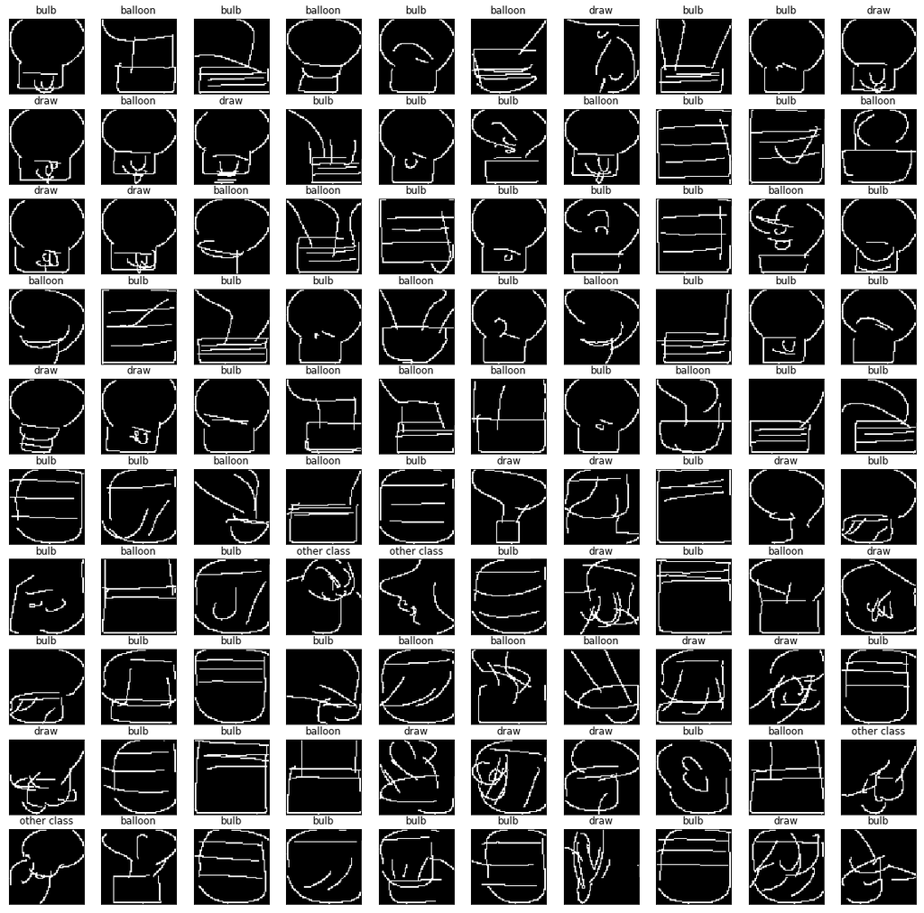

```
In 100 games, 26 of sketches look like balloon, 49 of sketches look like bulb, 25 of sketches look like others
penalty of player1: 2, penalty of player2: 2
player1 draw balloon, player2 draw ice
```

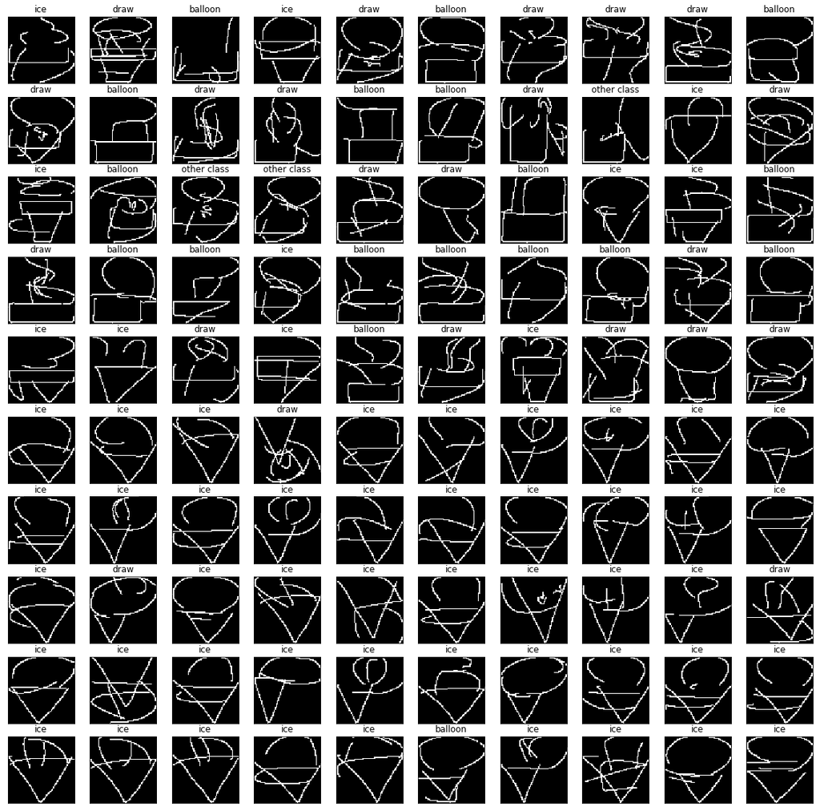

```
In 100 games, 18 of sketches look like balloon, 57 of sketches look like ice, 25 of sketches look like others
penalty of player1: 3, penalty of player2: 0
player1 draw balloon, player2 draw microphone
```

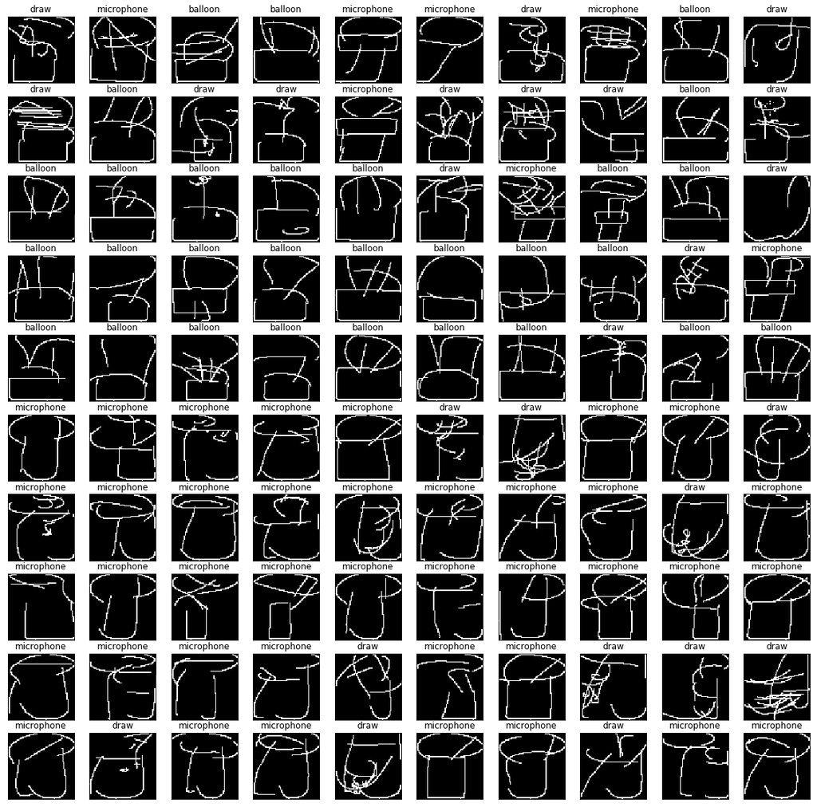

```
In 100 games, 29 of sketches look like balloon, 46 of sketches look like microphone, 25 of sketches look like others
penalty of player1: 0, penalty of player2: 0
player1 draw bulb, player2 draw balloon
```

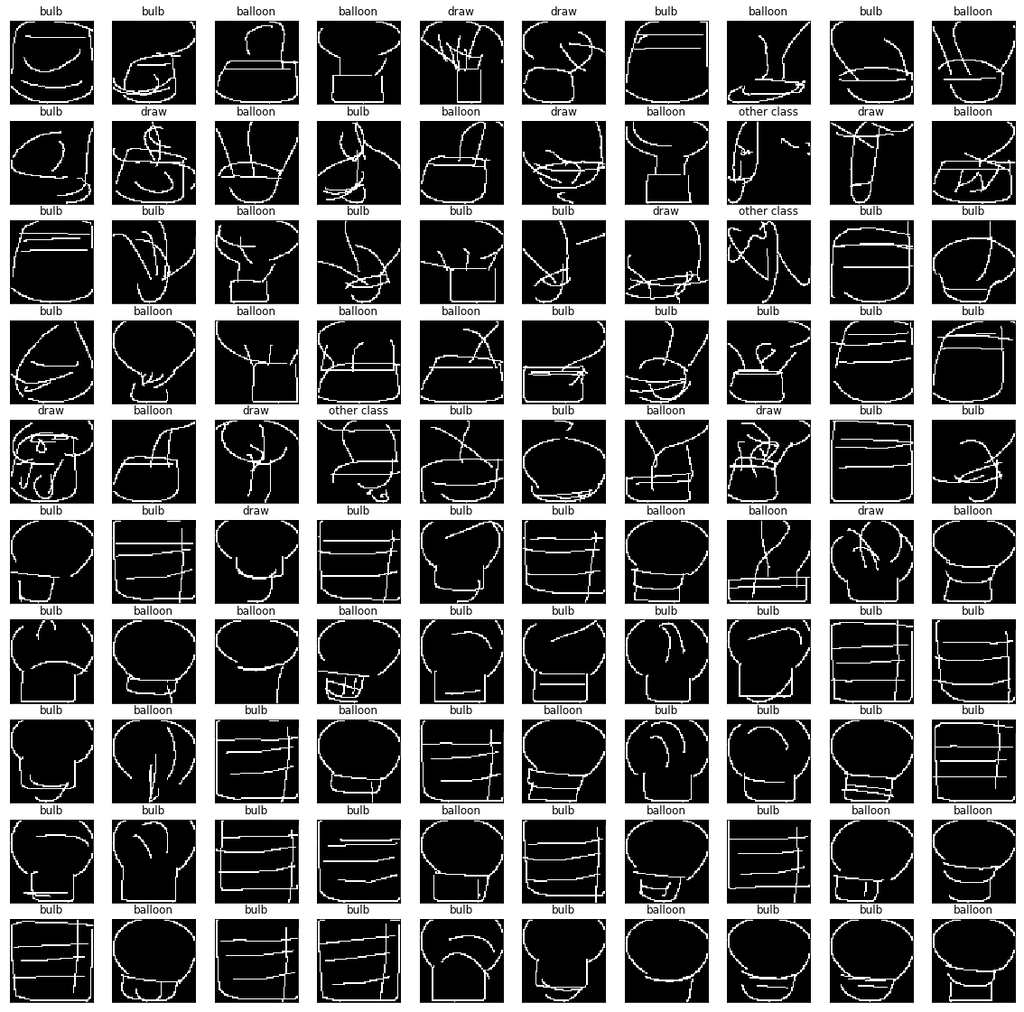

```
In 100 games, 55 of sketches look like bulb, 31 of sketches look like balloon, 14 of sketches look like others
penalty of player1: 3, penalty of player2: 0
player1 draw bulb, player2 draw ice
```

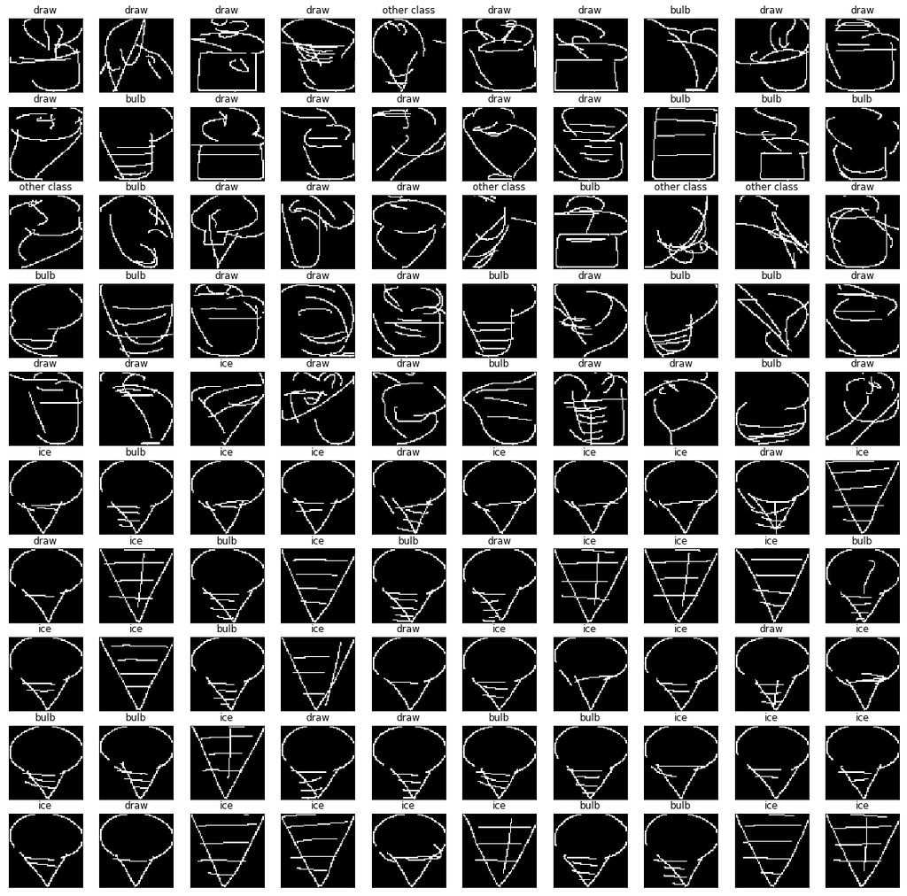

```
In 100 games, 25 of sketches look like bulb, 31 of sketches look like ice, 44 of sketches look like others
penalty of player1: 3, penalty of player2: 2
player1 draw bulb, player2 draw microphone
```

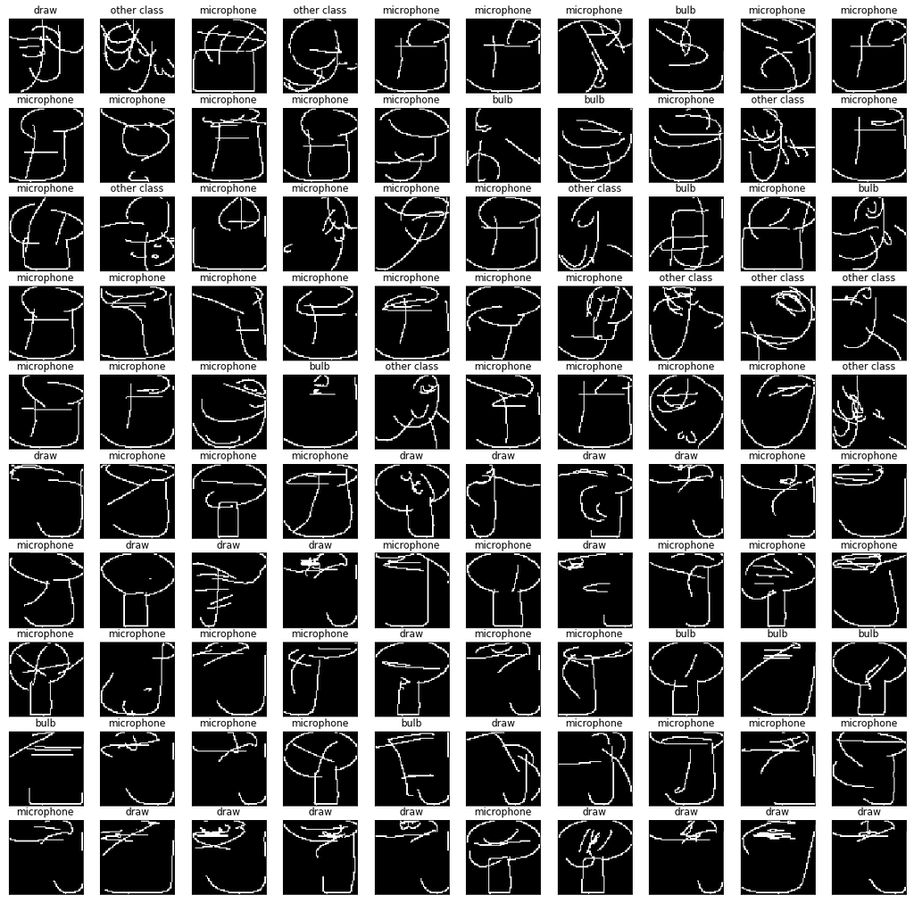

```
In 100 games, 11 of sketches look like bulb, 59 of sketches look like microphone, 30 of sketches look like others
penalty of player1: 5, penalty of player2: 5
player1 draw ice, player2 draw balloon
```

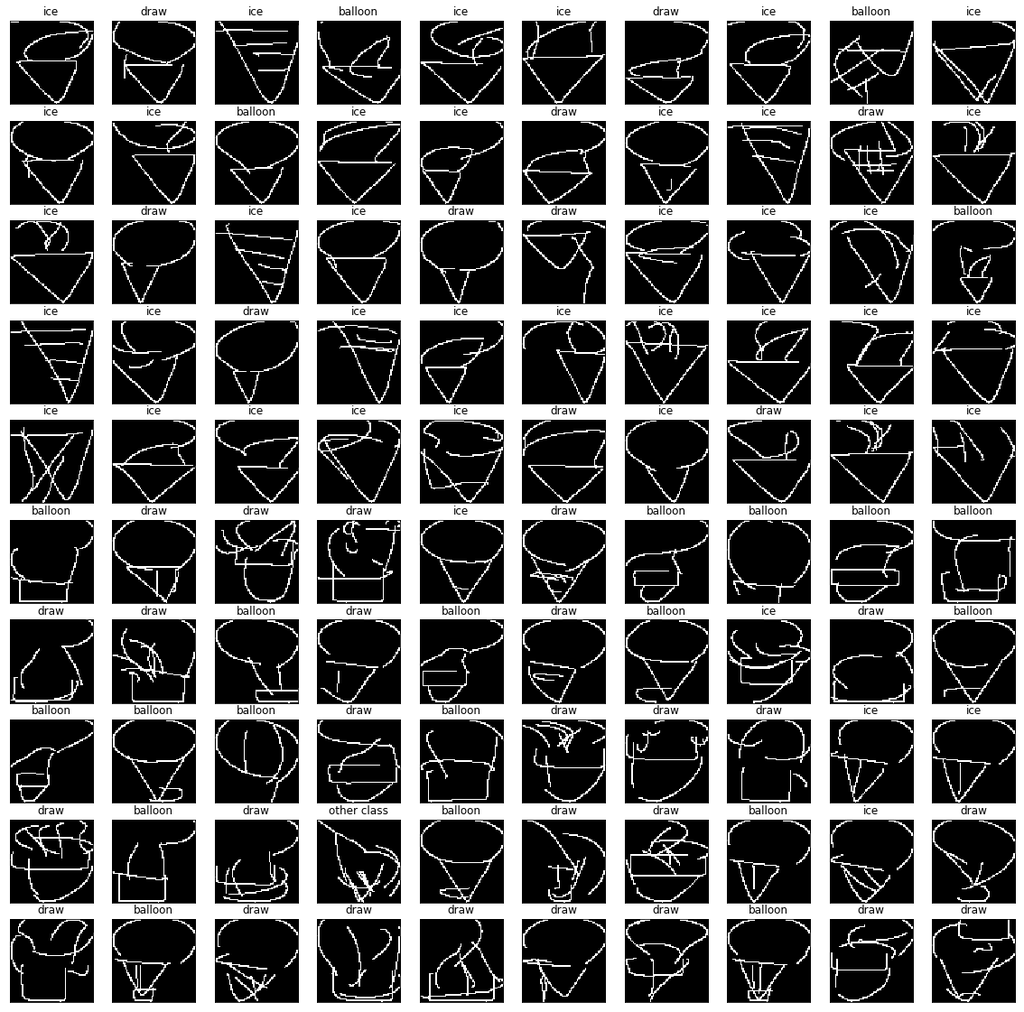

```
In 100 games, 41 of sketches look like ice, 22 of sketches look like balloon, 37 of sketches look like others
penalty of player1: 1, penalty of player2: 0
player1 draw ice, player2 draw bulb
```

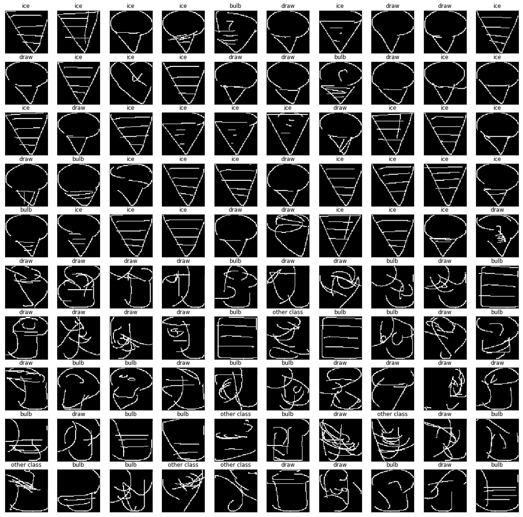

```
In 100 games, 32 of sketches look like ice, 24 of sketches look like bulb, 44 of sketches look like others
penalty of player1: 4, penalty of player2: 2
player1 draw ice, player2 draw microphone
```

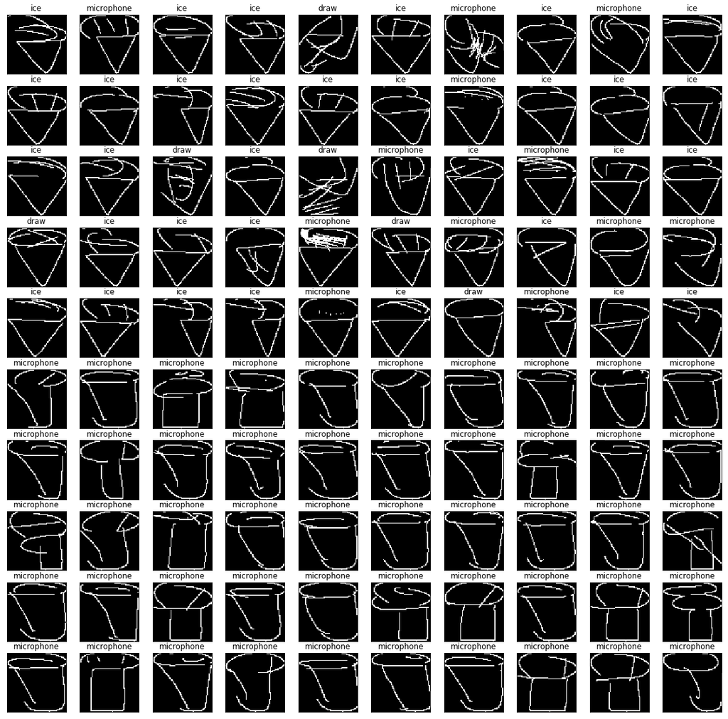

```
In 100 games, 32 of sketches look like ice, 62 of sketches look like microphone, 6 of sketches look like others
penalty of player1: 0, penalty of player2: 0
player1 draw microphone, player2 draw balloon
```

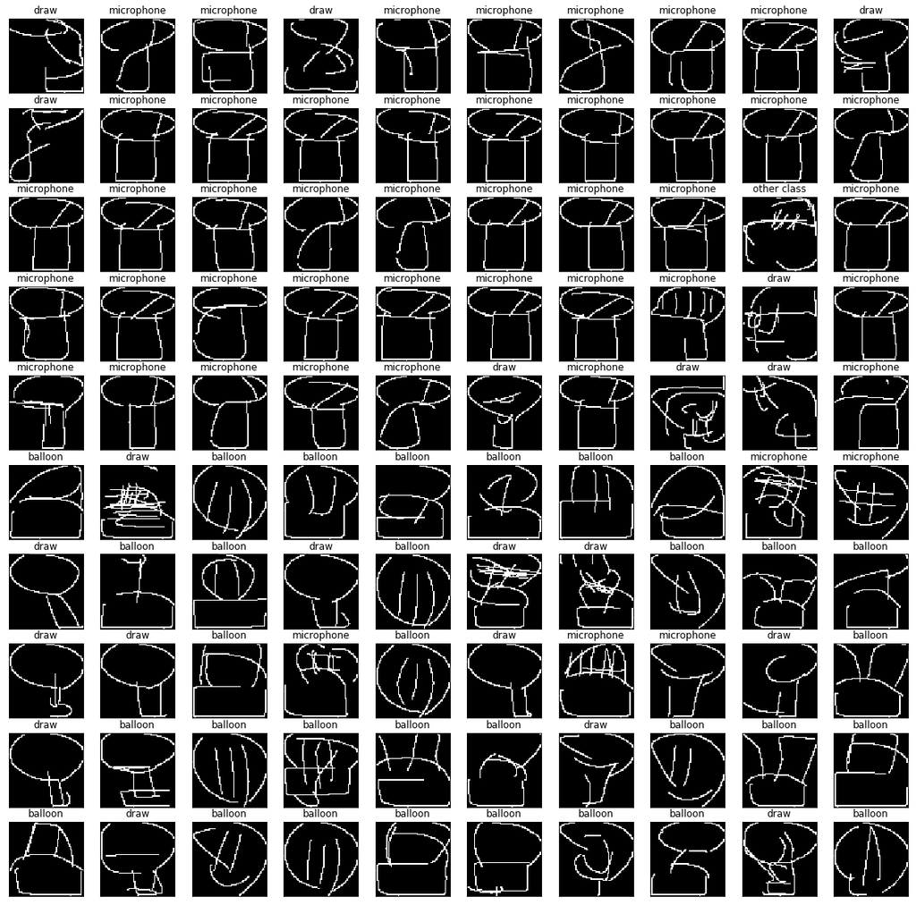

```
In 100 games, 46 of sketches look like microphone, 32 of sketches look like balloon, 22 of sketches look like others
penalty of player1: 1, penalty of player2: 0
player1 draw microphone, player2 draw bulb
```

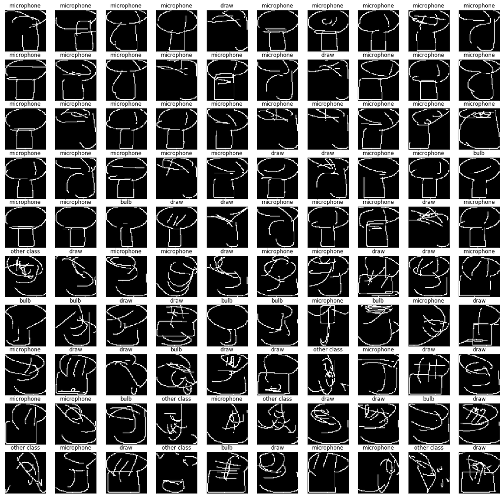

```
In 100 games, 56 of sketches look like microphone, 11 of sketches look like bulb, 33 of sketches look like others
penalty of player1: 3, penalty of player2: 4
player1 draw microphone, player2 draw ice
```

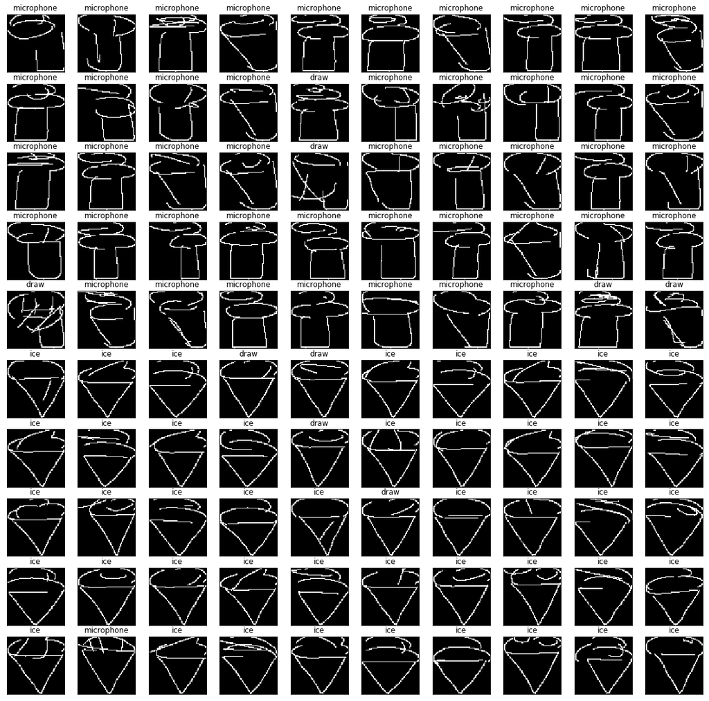

[output not shown]

```python
result, who_draw_the_strokes = play_game(draw_model, draw_model_ta_60)
```

You can see strokes generated by you and your opponent, they are presented in different color.

```python
for sketch, who_draw_the_stroke in zip(result[0][:10],
                                       who_draw_the_strokes[0][:10]):
  sketch = to_normal_strokes(sketch)
  sketch[:, :2] *= 30
  draw_strokes(
      sketch, show_pen_sequence=True, who_draw_the_stroke=who_draw_the_stroke)
```

[figure not shown]

## Hints

1. You can train a sketch-rnn by adding small perturbation to $(\Delta x, \Delta y)$, which may make it more robust (augmentation).
2. Following hint1, you can not sure if a perturbation is good for that sketch. In this case, you can train a classifier to give a score to the augmented sketch, treat it as reward and add it to loss function.
3. You can generate a stroke and let your opponent generate another stroke alternatively until the sketch is completed. In this case, you can not sure if your stroke after opponent's is good or bad. You can train a classifier to give a score to the sketch, treat it as reward and add it to loss function.

## Scoring

You are provided ta-60 and ta-80 model. If you win ta-60 model, you get a baseline score of 60. If you win ta-80 model, you get a baseline score of 80. Your model will compete with other team's model and get a rank in all teams. The first place get rank 20, while the last get 0. Rank score is interpolation between first place and last. Your final score is equal to (baseline score + rank score).

## Requirement

1. To prevent name conflict, name your model as team-{team_number}-{class}-{class_to_compete}, e.g.

   ```
   model = SRNN_Model(hps, model_name='team-1-balloon-bulb')
   ```

2. Create a team_{team_number}_model.py file. The file should contain a python class named `SRNN_Model` which has function `generate_stroke` and `load_model`, and another function not in class named `get_default_hparams`. Please refer to ta_60_model.py.

```
class SRNN_Model:
    def generate_stroke(self, sess, prev_sketch):
        pass
    def load_model(self, sess):
        pass

def get_default_hparams():
    pass
```

1. put weights of each class under checkpoints directory.
2. For example, team1's directory should looks like below:  
   |--checkpoints  
   | |--team-1-balloon-bulb  
   | |--team-1-balloon-ice  
   | |--team-1-balloon-microphone  
   | |--team-1-bulb-balloon  
   | |--team-1-bulb-ice  
   | |--team-1-bulb-microphone  
   | |--team-1-ice-balloon  
   | |--team-1-ice-bulb  
   | |--team-1-ice-microphone  
   | |--team-1-microphone-balloon  
   | |--team-1-microphone-bulb  
   | `--team-1-microphone-ice  
   `--team_1_model.py

## Precaution

1. Don't use ta-60 model or ta-80 model to fine tune your model.
2. Don't use ta-60 model or ta-80 model as initial weight.
3. Don't put your evalaution model in `generate_stroke` function to get stroke which is very confident to win the game.

## Submission

Zip files mentioned above and upload to google drive or other cloud. Submit share link to ilms.

## Competition timeline

2018/12/20 competition announced.  
2018/1/6 23:59(TW) competition deadline.  
2018/1/?? winner team share(will announce afterward).  
2018/1/10 23:59(TW) report deadline.

## Utility code

You may want to fine tune a model by a pretrain model, you can run following code to load a pretrained weight to target model.

```python
with tf.device('/cpu:0'):
  pretrain_model = SRNN_Model(hps, model_name='balloon')
  pretrain_model.load_model(sess)
model = SRNN_Model(hps, model_name='balloon-bulb')

# assign weights
srcs = tf.get_collection(tf.GraphKeys.TRAINABLE_VARIABLES, 'balloon/')
tars = tf.get_collection(tf.GraphKeys.TRAINABLE_VARIABLES, 'balloon-bulb/')
assert len(srcs) == len(tars)
update_ops = []
for src, tar in zip(srcs, tars):
  update_ops.append(tar.assign(src))
sess.run(update_ops)
```